# prelim_EDA_watershed_emma

```r
watershed <- read.csv("Data/combined_data.csv")

watershed[4:14] <- sapply(watershed[4:14], as.numeric)
names(watershed)[c(12,14)] <- c("NO3_N", "E_coli")
```

```r
library(tidyverse)
library(ggplot2)
library(tidymodels)
```

## R Markdown

```r
watershed %>%
  count(Site) %>%
  arrange(desc(n))
```

```
##          Site   n
## 1        Lime 333
## 2         Mud 272
## 3        Blue 269
## 4      Morgan 265
## 5        Bear 252
## 6         ICS 251
## 7         MCJ 250
## 8       Otter 248
## 9       NBear 147
## 10       ICLM 134
## 11     ICThom 132
## 12        ICN 114
## 13       MC42 107
## 14        Dry 102
```

[output cut: 33 more lines]

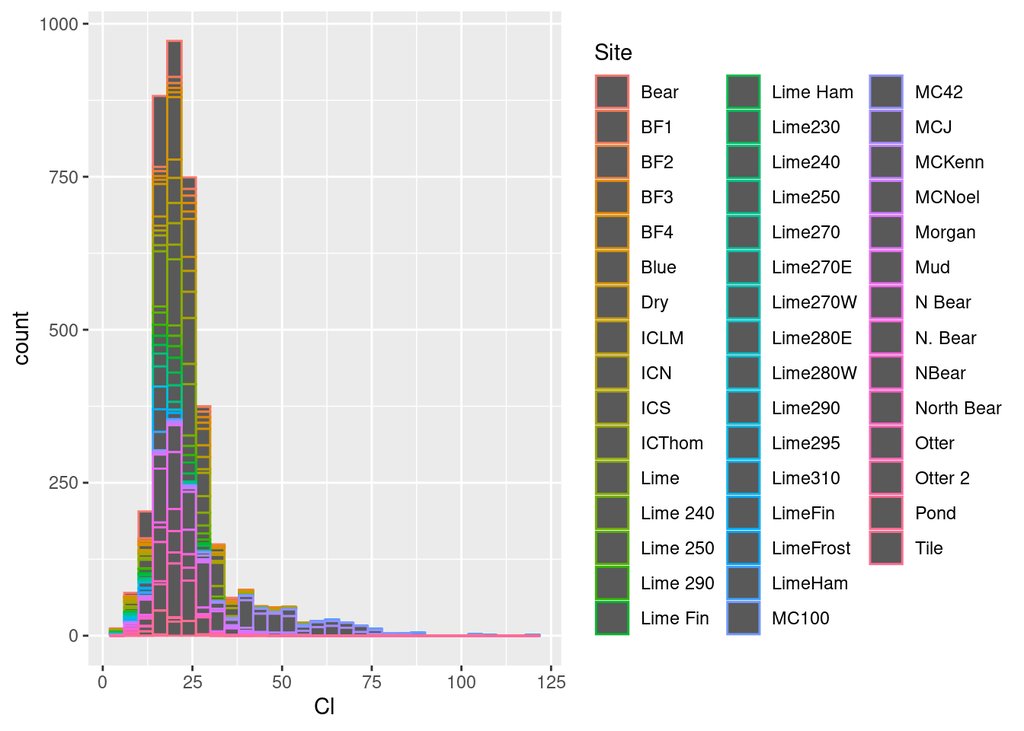

```r
ggplot(watershed, aes(x = Cl, color = Site)) +
  geom_histogram()
```

```r
og_rivers <- watershed %>%
filter(Site == c("Bear", "Blue", "Lime", "Morgan", "Mud", "N.Bear", "Otter"))
watershed %>%
  group_by(Site) %>%
  summarise(
            min = min(TSS, na.rm = TRUE),
            max = max(TSS, na.rm = TRUE),
            mean = mean(TSS, na.rm = TRUE),
            median = median(TSS, na.rm = TRUE),
            sd = sd(TSS, na.rm = TRUE)
            )
```

```
## # A tibble: 47 × 6
##    Site        min   max   mean median    sd
##    <chr>     <dbl> <dbl>  <dbl>  <dbl> <dbl>
##  1 Bear       0     534.  35.3   17.4  65.0
##  2 BF1        0.25   10    2.34   1.5   2.39
##  3 BF2        0.25   14    2.58   1.6   3.26
##  4 BF3        0.25  324.  31.6    7.55 63.1
##  5 BF4        0.4    37    6.99   2.7  10.2
##  6 Blue       0.25  141   15.7    9.26 20.4
##  7 Combo135 Inf    -Inf  NaN     NA    NA
##  8 Dry        0.4   168   20.6    6.1  37.6
##  9 ICLM       1.2   522   32.1   13.6  60.6
## 10 ICN        0.1   171.   7.70   0.59 21.2
## # … with 37 more rows
```

```r
og_rivers %>%
  group_by(Site) %>%
  summarise(
            min = min(TSS, na.rm = TRUE),
            max = max(TSS, na.rm = TRUE),
            mean = mean(TSS, na.rm = TRUE),
            median = median(TSS, na.rm = TRUE),
            sd = sd(TSS, na.rm = TRUE)
            )
```

```
## # A tibble: 6 × 6
##   Site     min   max  mean median    sd
##   <chr>  <dbl> <dbl> <dbl>  <dbl> <dbl>
## 1 Bear    0    202    30.8   14.5  41.2
## 2 Blue    0.4  141    18.3    9    27.4
## 3 Lime    0.8   71.3  10.9    5.5  15.9
## 4 Morgan  1    393.   33.0   13.3  71.5
## 5 Mud     0.4  374    40.2   22.4  73.0
## 6 Otter   0.33 302    27.5   10.5  56.5
```

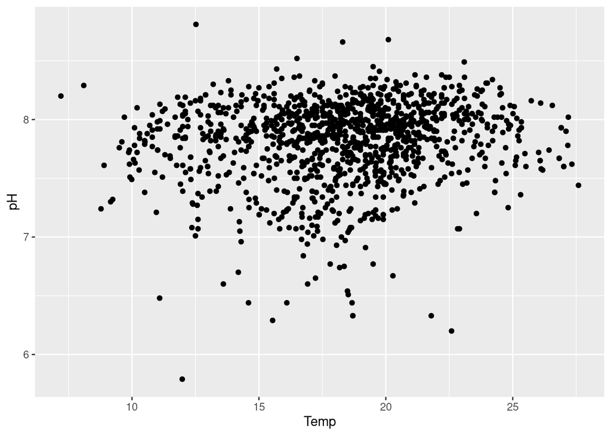

```r
ggplot(watershed, aes(x = Temp, y = pH)) +
         geom_point()
```

Graph of temp vs ph could be vaguely linear but show no clear correlation.

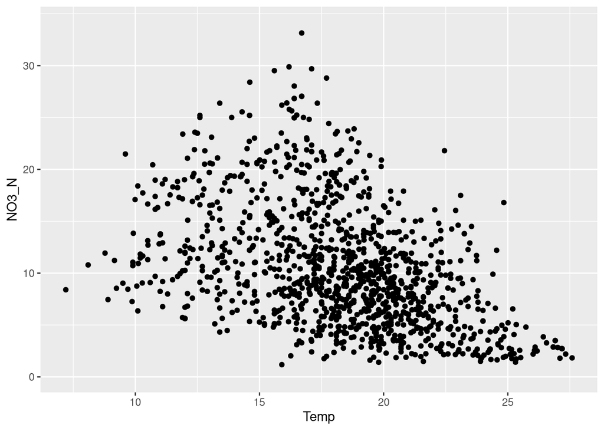

```r
ggplot(watershed, aes(x = Temp, y = NO3_N)) +
         geom_point()
```

```r
temp_vs_no3_fit <- linear_reg() %>%
  set_engine("lm") %>%
  fit(NO3_N ~ Temp, data = watershed)
  tidy(temp_vs_no3_fit)
```

```
## # A tibble: 2 × 5
##   term        estimate std.error statistic   p.value
##   <chr>          <dbl>     <dbl>     <dbl>     <dbl>
## 1 (Intercept)   24.3      0.783       31.0 1.37e-155
## 2 Temp          -0.749    0.0421     -17.8 3.39e- 63
```

```r
glance(temp_vs_no3_fit)
```

```
## # A tibble: 1 × 12
##   r.squared adj.r.squared sigma statistic  p.value    df logLik   AIC   BIC
##       <dbl>         <dbl> <dbl>     <dbl>    <dbl> <dbl>  <dbl> <dbl> <dbl>
## 1     0.208         0.208  5.19      317. 3.39e-63     1 -3703. 7412. 7428.
## # … with 3 more variables: deviance <dbl>, df.residual <int>, nobs <int>
```

Graph of temp vs. NO3 has a slightly negative, linear relationship (fans out in lower temps and narrows in higher temps - transform data?), indicating that as temperature increases, NO3 levels decrease.

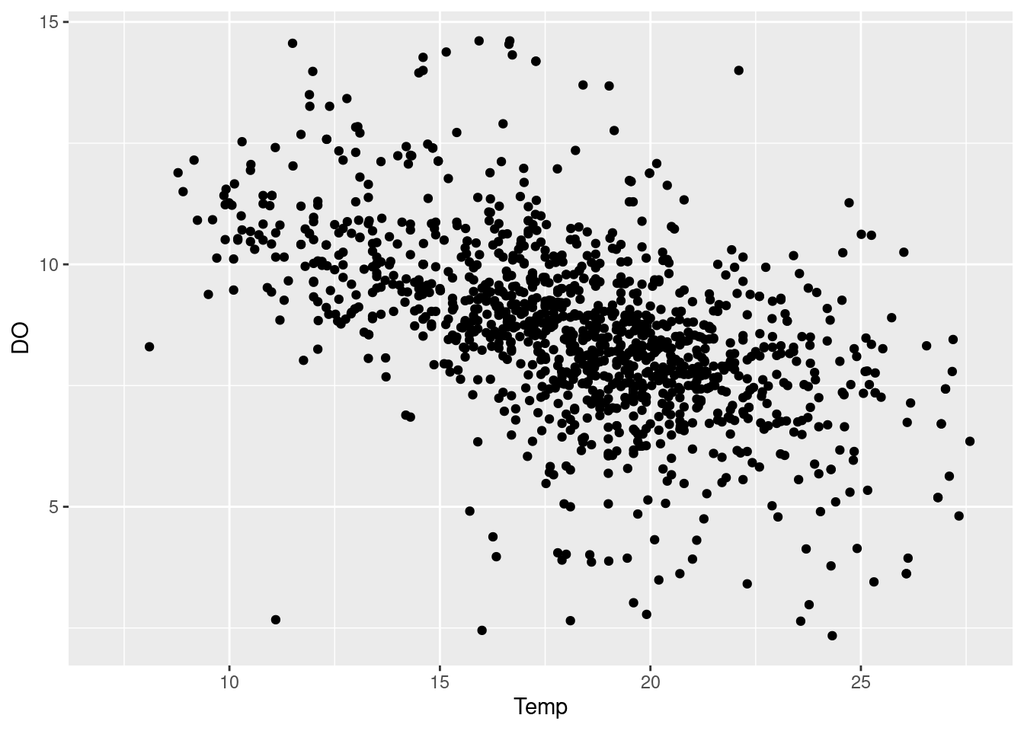

```r
ggplot(watershed, aes(x = Temp, y = DO)) +
         geom_point()
```

```r
temp_vs_DO_fit <- linear_reg() %>%
  set_engine("lm") %>%
  fit(DO ~ Temp, data = watershed)
  tidy(temp_vs_DO_fit)
```

```
## # A tibble: 2 × 5
##   term        estimate std.error statistic  p.value
##   <chr>          <dbl>     <dbl>     <dbl>    <dbl>
## 1 (Intercept)   13.7      0.235       58.3 0
## 2 Temp          -0.276    0.0126     -21.9 1.50e-89
```

```r
glance(temp_vs_DO_fit)
```

```
## # A tibble: 1 × 12
##   r.squared adj.r.squared sigma statistic  p.value    df logLik   AIC   BIC
##       <dbl>         <dbl> <dbl>     <dbl>    <dbl> <dbl>  <dbl> <dbl> <dbl>
## 1     0.286         0.285  1.55      479. 1.50e-89     1 -2227. 4460. 4476.
## # … with 3 more variables: deviance <dbl>, df.residual <int>, nobs <int>
```

Graph of temp vs. DO (dissolved oxygen?) shows a slightly negative, linear relationship. This indicates that as temperature increases, the levels of dissolved oxygen decrease. This is consistent with the packet and with how solubility works (solubility of a gas in liquid decreases as temperature increases). The linear model has an r-squared adj. of ~0.28, indicating that about 28% of the change in DO levels is explained by the change in temperature.

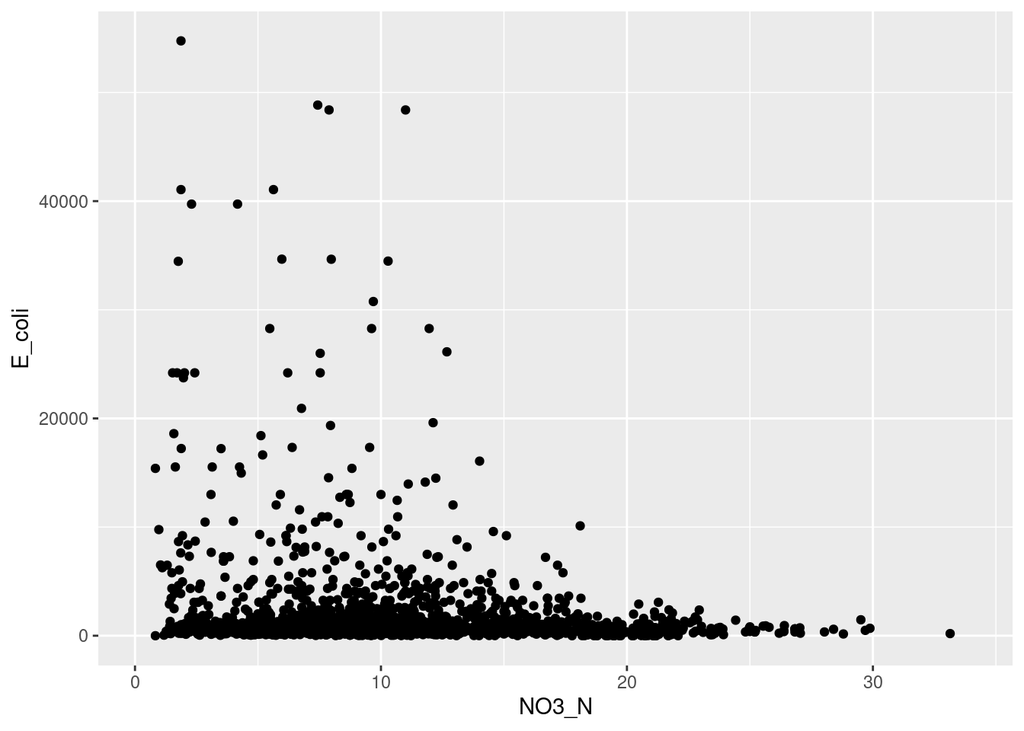

```r
ggplot(watershed, aes(x = NO3_N, y = E_coli)) +
         geom_point()
```

```r
no3_vs_ecoli_fit <- linear_reg() %>%
  set_engine("lm") %>%
  fit(E_coli ~ NO3_N, data = watershed)
  tidy(no3_vs_ecoli_fit)
```

```
## # A tibble: 2 × 5
##   term        estimate std.error statistic  p.value
##   <chr>          <dbl>     <dbl>     <dbl>    <dbl>
## 1 (Intercept)    2870.     199.      14.5  3.47e-45
## 2 NO3_N          -100.      17.6     -5.69 1.44e- 8
```

```r
glance(no3_vs_ecoli_fit)
```

```
## # A tibble: 1 × 12
##   r.squared adj.r.squared sigma statistic    p.value    df  logLik    AIC    BIC
##       <dbl>         <dbl> <dbl>     <dbl>      <dbl> <dbl>   <dbl>  <dbl>  <dbl>
## 1    0.0154        0.0150 4320.      32.4    1.44e-8     1 -20235. 40475. 40492.
## # … with 3 more variables: deviance <dbl>, df.residual <int>, nobs <int>
```

Graph of NO3_N vs E_coli has no clear pattern and a very low r-squared, indicating that NO3 levels aren’t correlated with E.coli levels. I had expected that E.coli levels would increases as NO3 levels increase because nitrates are a source of nurients for algae/bacteria, and because the papers and packet describe how increasing nitrate levels cause algal blooms/eutrophication. It’s possible the data needs to be transformed.